# Model update: change in dividend specification

Emma Holmes

2019-05-08

### Change to dividends

Previously, it was assumed that firms paid out dividends depending on the return on assets $\pi_{K_i} := \Pi_i / p K_i$, according to:
$$\Pi_{d_i} := \Delta(\pi_{K_i}) p K_i$$

It would be simpler to have dividends depend on the profit share instead, $\pi_{i} := \Pi_i / p Y_i$. This would give total dividends of
$$\Pi_{d_i} := \Delta(\pi_{i}) p Y_i$$

and then retained earnings would be
$$\Pi_{r_i} := \Pi_i - \Pi_{d_i} = p Y_i - w_i L_i - \delta_{\mathbf{D}^K_i} p K_i - r_i D_i + p \Upsilon_i - \Delta(\pi_i) p Y_i$$
$$= \left[ 1 - \Delta(\pi_i) \right] p Y_i - w_i L_i - \delta_{\mathbf{D}^K_i} p K_i - r_i D_i + p \Upsilon_i$$
where

$p$: price level in the whole country

$Y$: output in the region (after damages and abatement costs are accounted for)

$w_i$: wage in the region

$L_i$: employed persons in region

$\delta_{\mathbf{D}^K_i}$: standard depreciation rate plus any climate-related damages

$r_i$: nominal interest rate in the region

$D_i$: total nominal debt in the region

$\Upsilon_i$: net public transfers in the region (subsidies to green tech minus carbon tax revenue)

Recall that the dividend function $\Delta(\cdot)$ is of the form:

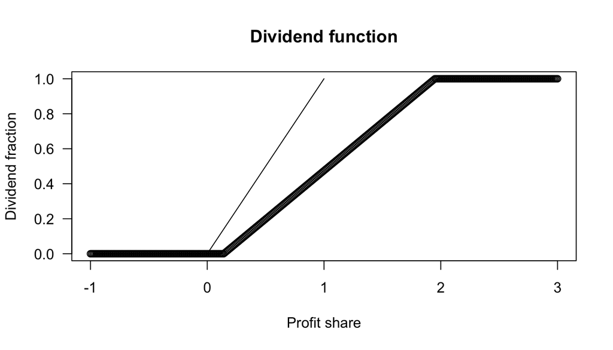

### Debt dynamics

Here is how debt, investment, and profits are now computed by the model.

Total profits:
$$\Pi_i := p Y_i - w_i L_i - \delta_{\mathbf{D}^K_i} p K_i - r_i D_i + p \Upsilon_i$$

Profit share:
$$\pi_i := \frac{\Pi_i}{p Y_i}$$

Dividends:
$$\Pi_{d_i} := \Delta(\pi_{i}) p Y_i$$
Retained earnings:
$$\Pi_{r_i} := \Pi_i - \Pi_{d_i}$$
Investment demand:

$$I^d_i := \rho_i \: \kappa(\pi_i) Y_i$$
where $\rho$ is the investment multiplier.

Debt demand:

$$D^d_i := p I^d_i + s_{rep_i} D_i - \delta_{\mathbf{D}^K_i} p K_i - \Pi_{r_i}$$
where $s_{rep}$ is is a parameter determining how much of the debt firms must pay back each time step.

Credit rationing:

$$CR_i := \tau_i \left(\frac{D_i}{p K_i} \right),$$

where $\tau_i (\cdot) \in [0,1]$ is an increasing linear function of the leverage ratio. This credit rationing function designates an upper limit, set by the banking sector in each region, on the supply of credit in the market. It is given by:

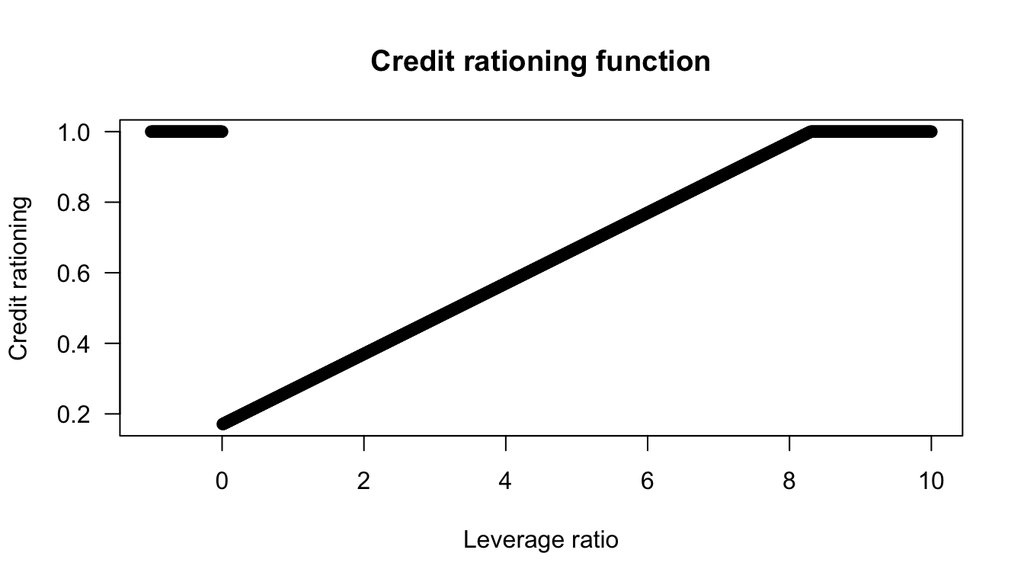

Debt dynamics:
$$\dot{D_i} := (1 - CR_i) D^d_i - s_{rep_i} D_i.$$

Real investment:

$$I_i := CR_i \left(\frac{\Pi_{r_i}}{p} + \delta_{\mathbf{D}^K_i} K_i - \frac{s_{rep_i} D_i}{p}\right) + (1 - CR_i) I^d_i$$

Capital dynamics:

$$\dot{K_i} := I_i - \delta_{\mathbf{D}^K_i} K_i.$$

### Results with previous specification

Here is the result when the code is run with the previous dividends specification, and “Stern” (convex) damages:

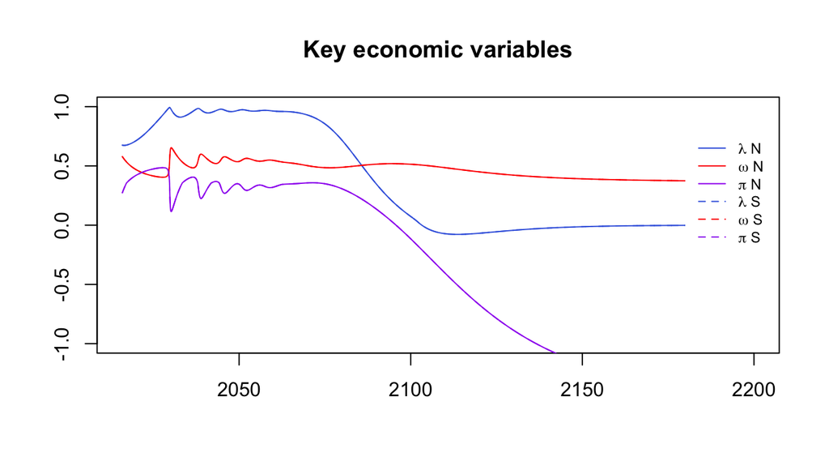

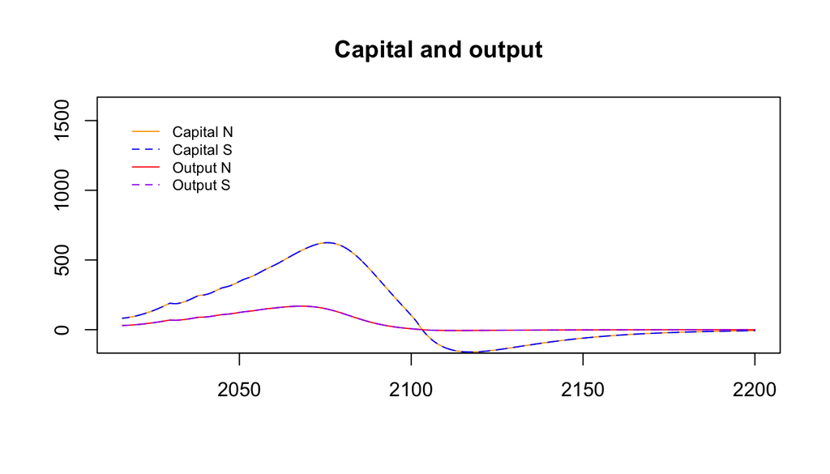

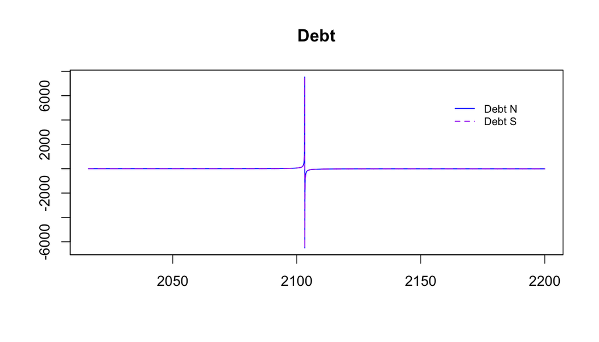

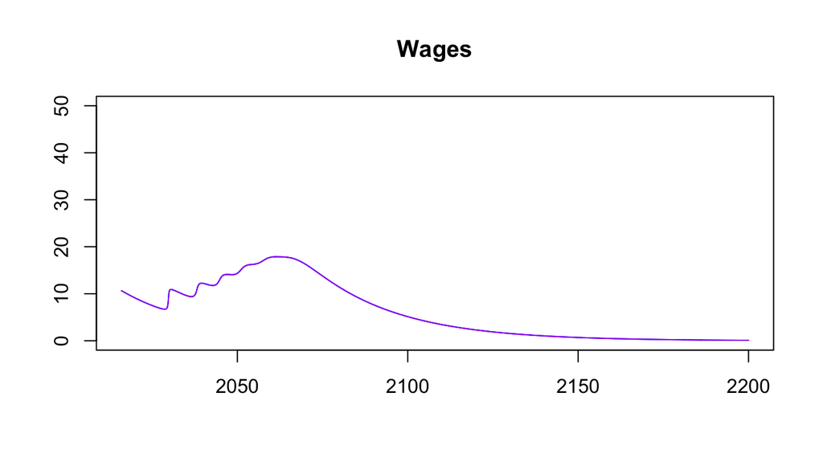

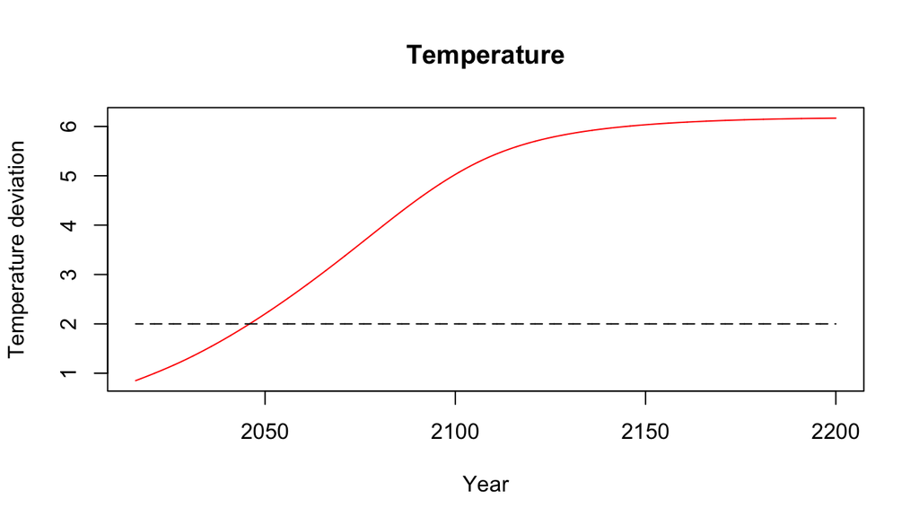

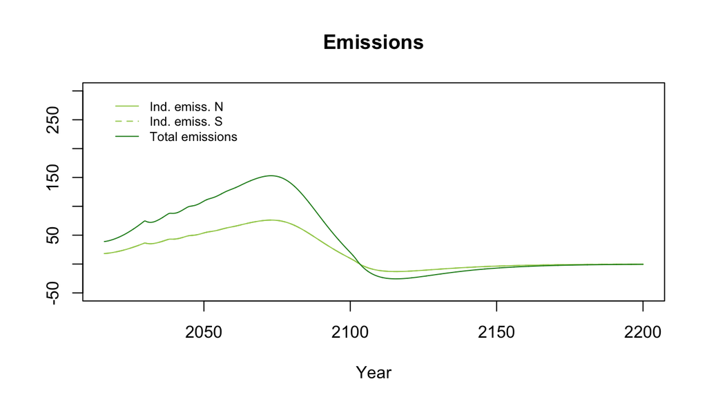

```r
# Set intial conditions (from Appendix D)
IC <- c(
  ### Separated
  # North
  Y_N       =  30,       # global GDP, in trillions of USD
  d_N       =  1.5328,   # private debt ratio of the economy
  lambda_N  =  0.6748,   # employment rate of the global economy
  omega_N   =  0.5782,   # wage share of the economy
  N_N       =  2.4127,   # Workforce of the (world) economy, in billions /2
  g_sigma_N =  -0.0105,  # Growth rate of the emissions intensity of the economy
  n_N       =  0.03,     # Emissions reduction rate
  E_ind_N   =  17.925,    # Industrial CO2-e emissions, in Gt CO2-e

  # South
  Y_S       =  30,       # global GDP, in trillions of USD
  d_S       =  1.5328,   # private debt ratio of the economy
  lambda_S  =  0.6748,   # employment rate of the global economy
  omega_S   =  0.5782,   # wage share of the economy
  N_S       =  2.4127,   # Workforce of the (world) economy, in billions /2
  g_sigma_S =  -0.0105,  # Growth rate of the emissions intensity of the economy
  n_S       =  0.03,     # Emissions reduction rate
  E_ind_S   =  17.925,    # Industrial CO2-e emissions, in Gt CO2-e

  # Unique
  CO2_AT   =  851,      # CO2-e concentration in the atmosphere layer, in Gt C
  CO2_UP   =  460,      # CO2-e concentration in the biosphere and upper ocean layer, in Gt C
  CO2_LO   =  1740,     # CO2-e concentration in the deep ocean layer, in Gt C
  E_land   =  2.6,      # Exogenous land use change CO2-e emissions, in Gt CO2-e
  p        =  1,        # Composite good price level
  p_BS     =  547.22,   # Backstop technology price level
  Temp     =  0.85,     # Temperature in the atmosphere, biosphere, and upper ocean layer, in degrees Celsius
  Temp_LO  =  0.0068    # Temperature in the deep ocean layer, in degrees Celsius
)

#=================================================================================
# Set up simulation
Time <- c(
  start         =     2016,
  end           =     2200,
  step          =     0.05,
  start_p_Car_N =     2016,
  start_p_Car_S =     2016
)

Active <- list(
  Damage_N     =   'Stern',       # None / Nordhaus / Weitzman / Stern
  Damage_S     =   'Stern',       # None / Nordhaus / Weitzman / Stern
  Damage_K     =    0,           # Fraction of damages allocated to capital
  Temperature  =    TRUE,        # T / F
  Lab_Prod_N   =   'constant',   # constant / Burke
  Lab_Prod_S   =   'constant',   # constant / Burke
  p_Car_N      =   'None',       # None / Low / Medium / High / Canada
  s_A_N        =   0,            # fraction of abatement costs subsidized by government
  p_Car_S      =   'None',       # None / Low / Medium / High / Canada
  s_A_S        =   0,            # fraction of abatement costs subsidized by government
  Phillips     =   'asymptotic', # linear / asymptotic
  Invest       =   'linear'      # linear / exponential
)


#================================================================================
## Run a scenario
# Computation
Sim      <- simulation(time             = Time,
                         init_sim         = IC,
                         pars             = Params,
                         active           = Active,
                         show_end_results = F,
                         show_graph = F
)
```

There is an explosion in debt, and capital, output, and emissions are negative around 2100, which is not a sensible outcome for the model.